# Multiple Linear Regression

Dr. Josh Jacobson

30 January 2026

*These lecture notes were originally developed by Dr. Kris Pruitt.*

The purpose of this lesson is to fit a multiple linear regression model using the least squares criterion. We will leverage built-in functions in `R` to execute the least squares algorithm and to measure the fit of the resulting models.

# Least Squares Criterion

The methodology for estimating a multiple linear regression model is very similar to that of the single-predictor (simple) version. The difference is that we now wish to predict a response $y$ based on $p>1$ predictor variables $x_1,x_2,...,x_p$. The population model is described by the following function.

$$y=\beta_0 +\beta_1 x_1 +\beta_2 x_2 + ...+ \beta_{p} x_{p} + \epsilon$$

This function suggests an underlying linear relationship between the explanatory variables and the response, while also acknowledging the presence of irreducible error ($\epsilon$). Just as with simple linear regression, we seek estimates $\hat{\beta}_0,\hat{\beta}_1,...,\hat{\beta_p}$ that provide the minimum value for the **residual sum of squares (RSS)** (shown below).

$$\begin{aligned}
\text{RSS} &= \boldsymbol{\epsilon}^T \cdot \boldsymbol{\epsilon} \\
&= (\textbf{y}-\textbf{X} \boldsymbol{\hat{\beta}})^T \cdot
(\textbf{y}-\textbf{X} \boldsymbol{\hat{\beta}})
\end{aligned}$$

Unlike the single-predictor problem, multiple linear regression includes an $X$ matrix with a potentially-large number of columns. For $n$ observations and $p$ predictor variables, the matrix form of the residual vector $\boldsymbol{\epsilon}=\textbf{y}-\textbf{X} \boldsymbol{\hat{\beta}}$ is written as:

$$\begin{pmatrix}
\epsilon_1 \\ \epsilon_2 \\ \vdots \\ \epsilon_n
\end{pmatrix}
=
\begin{pmatrix}
y_1 \\ y_2 \\ \vdots \\ y_n
\end{pmatrix}
-
\begin{pmatrix}
1 & x_{11} & x_{12} & \cdots & x_{1p} \\
1 & x_{21} & x_{22} & \cdots & x_{2p} \\
\vdots & \vdots & \vdots & & \vdots \\
1 & x_{n1} & x_{n2} & \cdots & x_{np}
\end{pmatrix}
\begin{pmatrix}
\hat{\beta_0} \\ \hat{\beta_1} \\
\vdots \\ \hat{\beta_p}
\end{pmatrix}$$

Despite the added complexity, the values for $\boldsymbol{\hat{\beta}}$ that minimize RSS remain the same.

$$\boldsymbol{\hat{\beta}} = (\textbf{X}^T \textbf{X})^{-1} \cdot
\textbf{X}^T \textbf{y}$$

Inverting a large $\textbf{X}^T \textbf{X}$ matrix by hand can be extremely cumbersome and time consuming. Thus, we employ modern computational power for the task.

# Numerical Example

As an example, we’ll explore a random sample of games from the 2017-2019 seasons of the National Basketball Association (NBA).

```r
# import data
bball <- read_csv("basketball.csv")
```

Suppose we want to predict a team’s margin of victory (MOV) based on various performance metrics. Let’s review the data and discuss the available metrics.

```r
# review data structure
glimpse(bball)
```

```
## Rows: 999
## Columns: 10
## $ season  <dbl> 2017, 2017, 2017, 2019, 2017, 2019, 2018, 2019, 2019, 2017, 20…
## $ game_id <chr> "c7b26b9d-92dd-44cb-965f-711b0a334ee2", "cbb58bbd-fa19-4e86-87…
## $ team    <chr> "UTA", "NO", "IND", "POR", "UTA", "CLE", "ATL", "MIA", "DET", …
## $ X1PP    <dbl> 0.5769231, 0.8333333, 0.6774194, 0.6538462, 0.7647059, 0.73913…
## $ X2PP    <dbl> 0.6511628, 0.5161290, 0.6136364, 0.6400000, 0.5625000, 0.41818…
## $ X3PP    <dbl> 0.3870968, 0.3000000, 0.3846154, 0.2564103, 0.2727273, 0.45945…
## $ AST     <dbl> 24, 23, 20, 22, 11, 26, 36, 25, 23, 27, 31, 29, 35, 19, 28, 35…
## $ OREB    <dbl> 7, 2, 8, 10, 9, 16, 15, 9, 9, 5, 10, 7, 4, 18, 13, 11, 15, 9, …
## $ TO      <dbl> 15, 15, 14, 11, 13, 14, 9, 13, 13, 9, 20, 17, 16, 20, 15, 10, …
## $ MOV     <dbl> 10, -19, 4, -12, -15, 7, 1, -13, 15, 30, 13, 6, 15, 4, -6, 29,…
```

The variables `X1PP`, `X2PP`, and `X3PP` provide the free-throw (one-point), two-point, and three-point shooting percentages, respectively. The remaining statistics represent assists, offensive rebounds, turnovers, and margin of victory. Now let’s display the associations between individual metrics and the response.

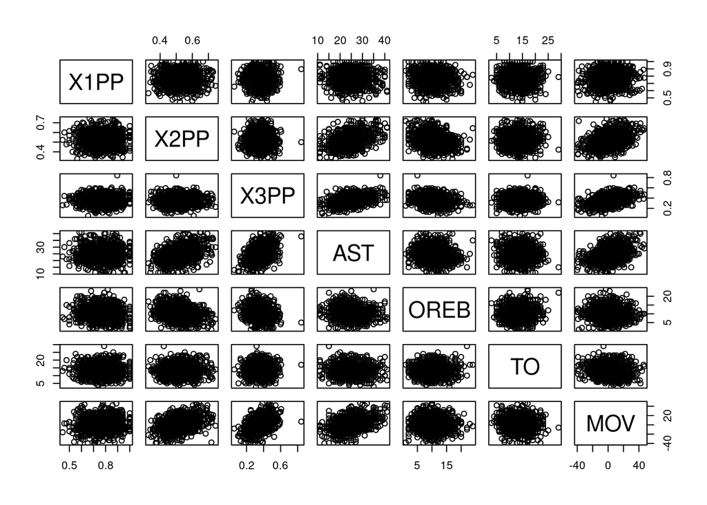

```r
# remove unwanted variables
bball_temp <- bball %>%
  select(-season, -game_id, -team)

# display correlation matrix
pairs(bball_temp)
```

From the scatter plots, it appears two-point percentage, three-point percentage, and assists are linearly correlated with margin of victory. To start, let’s fit a simple linear regression model with two-point percentage.

```r
# fit model
model1 <- lm(MOV ~ X2PP, data = bball)

# review summary output
summary(model1)
```

```
##
## Call:
## lm(formula = MOV ~ X2PP, data = bball)
##
## Residuals:
##     Min      1Q  Median      3Q     Max
## -54.870  -8.684   0.420   8.600  37.358
##
## Coefficients:
##             Estimate Std. Error t value Pr(>|t|)
## (Intercept)  -37.307      3.054  -12.22   <2e-16 ***
## X2PP          75.377      5.774   13.05   <2e-16 ***
## ---
## Signif. codes:  0 '***' 0.001 '**' 0.01 '*' 0.05 '.' 0.1 ' ' 1
##
## Residual standard error: 13.29 on 997 degrees of freedom
## Multiple R-squared:  0.146,  Adjusted R-squared:  0.1451
## F-statistic: 170.4 on 1 and 997 DF,  p-value: < 2.2e-16
```

Thus our best-fit linear model is $MOV=75.38 \cdot X2PP-37.31$. How well does this model explain the variability in margin of victory? Based on residual standard error (RSE), the data differs from the model by about 13 points. Furthermore, the R-squared value suggests only 15% of the variability in margin of victory is explained by two-point shooting percentage. Can we improve on the model’s fit by adding more explanatory variables? Let’s add three-point percentage to the model and see what happens.

```r
# fit model
model2 <- lm(MOV ~ X2PP + X3PP, data = bball)

# review summary output
summary(model2)
```

```
##
## Call:
## lm(formula = MOV ~ X2PP + X3PP, data = bball)
##
## Residuals:
##     Min      1Q  Median      3Q     Max
## -47.509  -8.515   0.009   8.019  34.417
##
## Coefficients:
##             Estimate Std. Error t value Pr(>|t|)
## (Intercept)  -61.665      3.104  -19.86   <2e-16 ***
## X2PP          75.575      5.138   14.71   <2e-16 ***
## X3PP          67.419      4.156   16.22   <2e-16 ***
## ---
## Signif. codes:  0 '***' 0.001 '**' 0.01 '*' 0.05 '.' 0.1 ' ' 1
##
## Residual standard error: 11.83 on 996 degrees of freedom
## Multiple R-squared:  0.3245, Adjusted R-squared:  0.3231
## F-statistic: 239.2 on 2 and 996 DF,  p-value: < 2.2e-16
```

Now our best-fit linear model is $MOV=75.58 \cdot X2PP+67.42 \cdot X3PP -61.67$. This model appears to be a better fit. The error is down to about 12 points, on average, and we can explain about 32% of the variance in margin of victory.

> When comparing models with a different number of explanatory variables, we should be using the **Adjusted R-squared**. The reason is that the original R-squared will *always* increase when adding more explanatory variables. This is true even if the explanatory variable is completely uncorrelated with the response. So, we adjust R-squared in the following manner to correct for this issue.

$$\text{Adjusted} \; R^2= 1- \frac{\text{RSS}}{\text{TSS}} \cdot
\frac{n-1}{n-1-p}$$

Based on this adjustment, a model is penalized for additional explanatory variables, if the RSS is not reduced. Let’s go one step further and add assists.

```r
# fit model
model3 <- lm(MOV ~ X2PP + X3PP + AST, data = bball)

# review summary output
summary(model3)
```

```
##
## Call:
## lm(formula = MOV ~ X2PP + X3PP + AST, data = bball)
##
## Residuals:
##     Min      1Q  Median      3Q     Max
## -46.751  -8.537   0.168   8.117  36.184
##
## Coefficients:
##              Estimate Std. Error t value Pr(>|t|)
## (Intercept) -61.35970    3.09547 -19.822  < 2e-16 ***
## X2PP         67.70250    5.83042  11.612  < 2e-16 ***
## X3PP         61.20591    4.69028  13.050  < 2e-16 ***
## AST           0.24591    0.08714   2.822  0.00487 **
## ---
## Signif. codes:  0 '***' 0.001 '**' 0.01 '*' 0.05 '.' 0.1 ' ' 1
##
## Residual standard error: 11.79 on 995 degrees of freedom
## Multiple R-squared:  0.3299, Adjusted R-squared:  0.3278
## F-statistic: 163.3 on 3 and 995 DF,  p-value: < 2.2e-16
```

Now our best-fit linear model is $MOV=67.70 \cdot X2PP+61.21 \cdot X3PP+0.25 \cdot AST -61.36$. Including assists provided very little improvement in the model’s fit based on RSE and Adjusted R-squared. Why do you think this is the case?

We should always be careful when interpreting the coefficients in a multiple linear regression model. For example, the estimated value ($\hat{\beta}_1$) for the two-point percentage coefficient assumes three-point percentage and assists are **held constant**. So, a 1 percentage-point increase in two-point shooting is expected to increase the margin of victory by 0.677 point, when the other two statistics are held constant. Notice, we had to adjust decimal places to account for representing the shooting percentage as a decimal.